# Questionnaire e-TAC sur le Travail collectif et outils numériques en milieu scolaire: présentation des questions

- interrogation des enseignants par Internet via un [questionnaire web](https://enquetes.univ-lorraine.fr/index.php/629828?lang=fr) transmis aux directeurs des écoles primaires et élémentaires et aux principaux des collèges de Moselle, via les adresses académiques listées dans l’[annuaire de l’éducation](http://www.education.gouv.fr/pid24301/annuaire-de-l-education.html)
- information préalable par le DASEN pour favoriser les retours.

## Validation du questionnaire.

### Temps moyen de réponse et validation de l’ensemble du questionnaire

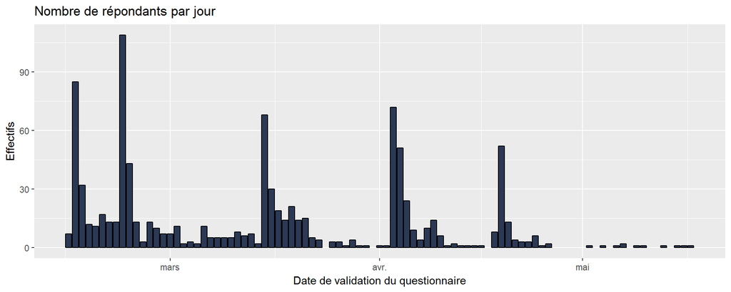

Une partie d’entre-eux l’a toutefois quitté en ne l’ayant pas intégralement ou du tout validé. Une première indication des abandons est fournie par le chronométrage de chaque groupe de questions. Si le temps de passation est renseigné pour un groupe et non renseigné pour le suivant, le questionnaire à été abandonné sur ce premier groupe. S’il est renseigné pour le dernier groupe de questions (H), le questionnaire a été entièrement complété, en 23.4 minutes en moyenne.

On compte ainsi 972 réponses complêtes, auxquelles s’ajoutent celles qui ont validé les parties successives et les non réponses.

Parties validées avant abandon

|  | n | % |
| --- | --- | --- |
| A Le travail collectif des enseignants | 107 | 6.4 |
| Abis Le travail collectif des enseignants (travail isolé) | 19 | 1.1 |
| B Le contexte professionnel du travail entre enseignants | 56 | 3.3 |
| C L’usage du numérique par les enseignants | 46 | 2.7 |
| D Le travail collectif des élèves | 43 | 2.6 |
| E Les outils du travail en classe | 48 | 2.8 |
| F Bilan et perspectives sur le numérique à l’école | 23 | 1.4 |
| G Ecole et territoire | 11 | 0.7 |
| H Profil socio-professionnel | 972 | 57.7 |
| Non Disponibles | 360 | 21.4 |
| Total | 1685 | 100.0 |

### Les abandons sont-ils traitables?

Parmi les 107 enseignants n’ayant renseigné que le premier groupe de questions, 50 déclarent au moins l’une des activités collectives proposées en choix multiple et 39 n’en sélectionnent aucune, sans pour autant déclarer travailler seuls. De même parmi les 56 répondants ayant abandonné au deuxième groupe de questions (B): 14 déclarent au moins l’une des activités collectives proposées et 34 n’en sélectionnent aucune, sans déclarer travailler seuls. En somme, 84% des répondants ayant abandonné aux deux premiers groupes de questions n’auraient pas travaillé seuls depuis septembre 2017. Ils sont proportionnellement et numériquement plus nombreux à ne pas sélectionner les modalités d’activité collective proposées en choix multiple: 44.8% pourraient se reconnaitre dans d’autres modalités d’activité collective.

Ces réponses aux premiers groupes de questions ne sont cependant traitables que si, à défaut de sélectionner une modalité de travail collectif ou déclarer travailler seul depuis septembre 2017 à la première question, elles renseignent le champ “autre” dont le contenu est repris dans les questions suivantes. Or cette condition n’est ni respectée par 35 des 39 réponses concernées dans le groupe A, ni par 33 des 34 réponses concernées dans le groupe B. Ces 68 réponses seront donc considérées comme des manipulations exploratoires du questionnaire et ajoutées aux 360 réponses non disponibles initiales.

Parties validées avant abandon hors manipulation exploratoires

|  | n | % |
| --- | --- | --- |
| A Le travail collectif des enseignants | 72 | 4.3 |
| Abis Le travail collectif des enseignants (travail isolé) | 19 | 1.1 |
| B Le contexte professionnel du travail entre enseignants | 23 | 1.4 |
| C L’usage du numérique par les enseignants | 46 | 2.7 |
| D Le travail collectif des élèves | 43 | 2.6 |
| E Les outils du travail en classe | 48 | 2.8 |
| F Bilan et perspectives sur le numérique à l’école | 23 | 1.4 |
| G Ecole et territoire | 11 | 0.7 |
| H Profil socio-professionnel | 972 | 57.7 |
| Non Disponibles | 428 | 25.4 |
| Total | 1685 | 100.0 |

# A. Le travail collectif des enseignants

# 1)* Depuis septembre 2017, quelles activités vous ont conduit à travailler directement avec d’autres enseignants?

## Déclaration des activités collectives

Parmi les 972 enseignants ayant complété l’ensemble du questionnaire (jusqu’au groupe H), 781 (80.3%) déclarent à la première question avoir préparé des cours, des évaluations ou un projet avec au moins un de leurs collègues depuis septembre 2017. 45 ne déclarent aucune de ces activités collectives, mais n’indiquent pas non plus avoir travaillé seuls: ils ont pu valider la question en renseignant d’autres activités, dans un champ texte.

|  | #Total |
| --- | --- |
| dH$Collab |  |
| activité parmi celles proposées | 80.3 |
| autres types d’activités collectives | 4.6 |
| je travaille seul depuis septembre 2017 | 15 |
| #Total cases | 972 |

85% des réponses complètes sont founies par des enseignants n’ayant pas déclaré avoir travaillé seuls depuis septembre 2017, sans différence entre école élémentaire et collège.

`EtabType.reg` (p 37.4%)

|  | #Total | CLG | Ecole |
| --- | --- | --- | --- |
| dH$Collab |  |  |  |
| travaille seul | 15 | 14.1 | 16.4 |
| activités collectives | 85 | 85.9 | 83.6 |
| #Total cases | 972 | 575 | 397 |

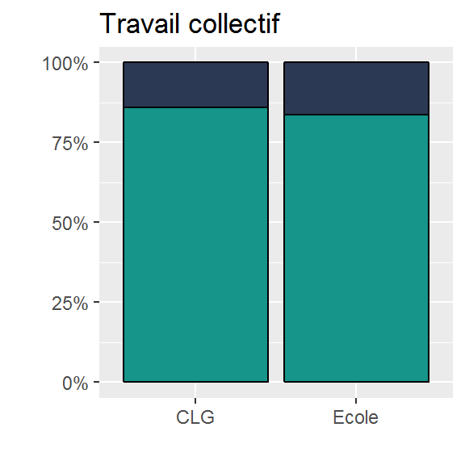

## Multiplicité des activités collectives

Parmi les 826 enseignants n’ayant pas déclaré avoir travaillé seuls, 471 (57%) sont engagés dans plus d’une activité. Le nombre d’activités déclarées est similaire au collège et à l’école.

Le nombre d’activités déclarées permet d’identifier 10 individus ayant validé cette partie sans avoir déclaré d’activité collective ni avoir travaillé seuls: on considérera désormais 816 enseignants ayant préparé des activités collectives ou projets avec leurs collègues.

`NbAct` (p 7.7%)

## Types d’activités collectives

*j’ai élaboré des:*

| Type d’activité | Effectif au collège | Effectif en élémentaire | % au collège | % en élémentaire | % Global |
| --- | --- | --- | --- | --- | --- |
| cours ou séquences d’activités `Cours` | 299 | 149 | 61.1 | 45.6 | 54.9 |
| travaux d’évaluations pour les élèves `Eval` | 195 | 71 | 39.9 | 21.7 | 32.6 |
| projets d’interclasse `InterCl` | 166 | 144 | 33.9 | 44 | 38 |
| projets de cycle ou d’établissement `Etab` | 137 | 183 | 28 | 56 | 39.2 |
| projets inter-établissements `InterEtab` | 41 | 66 | 8.4 | 20.2 | 13.1 |
| projets académiques `Academique` | 10 | 6 | 2 | 1.8 | 2 |
| autres types d’activités collectives `CollabOther` | 85 | 32 | 17.4 | 9.8 | 14.5 |
| Total | 489 | 327 |  |  | n =816 |

## *Préparation collective de cours et d’évaluation*

*Parmi les 448 enseignants qui ont déclaré avoir préparé cours ou séquences d’activités avec leurs collègues depuis septembre, 342 (76.3%) les ont ensuite donnés en classes séparées, et 106 (23.7%) en classe commune.*

`Cours` (p 0%)

*j’ai élaboré des cours ou séquences d’activités…*

|  | #Total | CLG | Ecole |
| --- | --- | --- | --- |
| dHC$Cours |  |  |  |
| Non | 45.1 | 38.9 | 54.4 |
| Oui | 54.9 | 61.1 | 45.6 |
| #Total cases | 816 | 489 | 327 |

`Eval` (p 8.910^{-6}%)

*j’ai élaboré des travaux d’évaluations pour les élèves…*

|  | #Total | CLG | Ecole |
| --- | --- | --- | --- |
| dHC$Eval |  |  |  |
| Non | 67.4 | 60.1 | 78.3 |
| Oui | 32.6 | 39.9 | 21.7 |
| #Total cases | 816 | 489 | 327 |

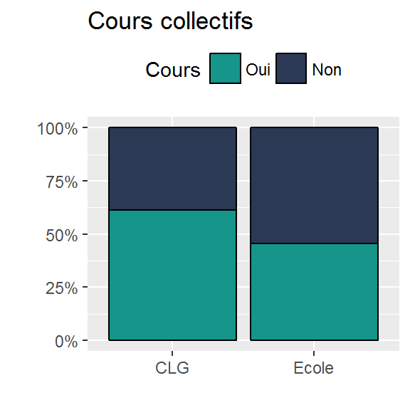

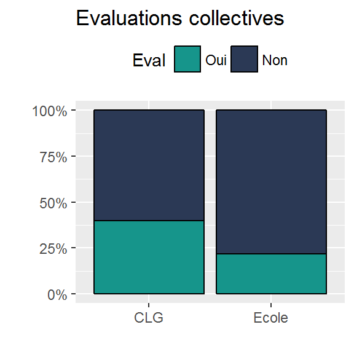

## Préparation collective de cours et d’évaluation ensuite donnés en classes communes

`CoursD` (p NaN%)

*j’ai élaboré des cours ou séquences d’activités…*

|  | #Total | CLG | Ecole |
| --- | --- | --- | --- |
| dHCCours$CoursD |  |  |  |
| Non |  |  |  |
| que chacun fait dans sa propre classe | 76.3 | 73.2 | 82.6 |
| que nous faisons en classe commune | 23.7 | 26.8 | 17.4 |
| #Total cases | 448 | 299 | 149 |

`EvalD` (p 8.6%)

*j’ai élaboré des travaux d’évaluations pour les élèves…*

|  | #Total | CLG | Ecole |
| --- | --- | --- | --- |
| dHCEval$EvalD |  |  |  |
| que chacun fait dans sa propre classe | 74.8 | 71.8 | 83.1 |
| que nous faisons en classe commune | 25.2 | 28.2 | 16.9 |
| #Total cases | 266 | 195 | 71 |

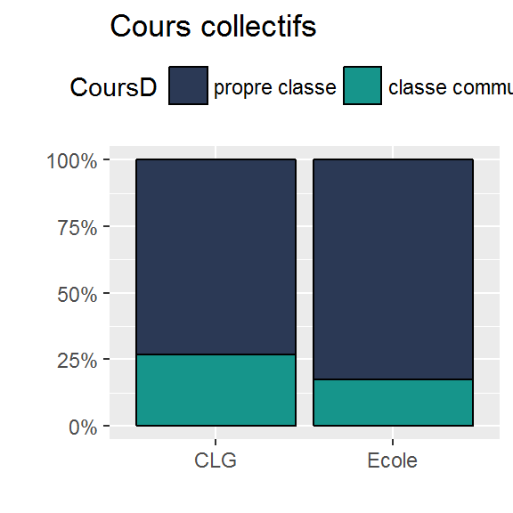

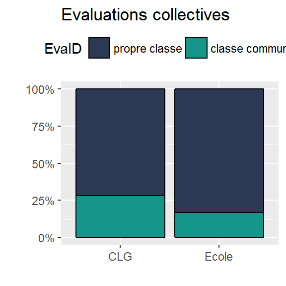

## Préparation collective de projets

Parmi les 816 enseignants qui ont déclaré avoir préparé une activité ou un projet avec leurs collègues depuis septembre, 530 (65%) ont préparé des projets.

`Projets` (p 5.110^{-10}%)

*j’ai élaboré des projets …*

|  | #Total | CLG | Ecole |
| --- | --- | --- | --- |
| dHC$Projets |  |  |  |
| Non | 35 | 44.6 | 20.8 |
| Oui | 65 | 55.4 | 79.2 |
| #Total cases | 816 | 489 | 327 |

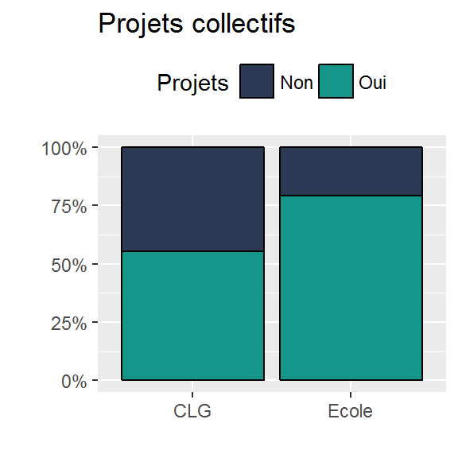

## Projets par type

Parmi les 530 enseignants qui ont déclaré avoir préparé un projet avec leurs collègues depuis septembre, 310 (58.5%) ont préparé des projets interclasse.

*j’ai élaboré des projets …*

`InterCl` (p 21.8%) `Etab` (p 3.510^{-4}%) `InterEtab` (p 0.4%) `Academique` (p 50.3%)

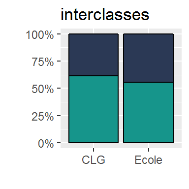

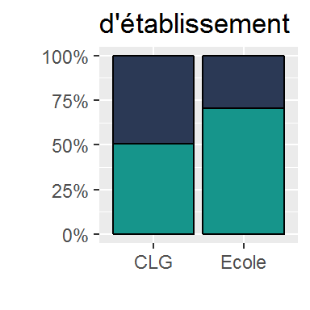

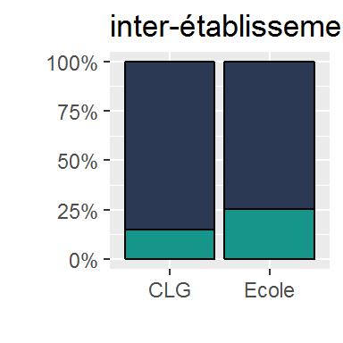

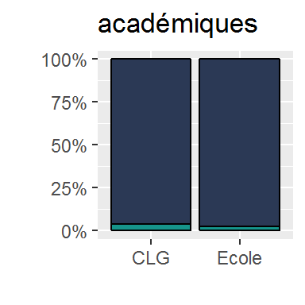

## autres activités collectives

Parmi les 816 enseignants qui ont déclaré avoir préparé une activité ou un projet avec leurs collègues depuis septembre, 117 (14.3%) ont déclaré d’autres activités collectives.

*j’ai élaboré d’autres activités collectives …*

`CollabOther` (p 0.3%)

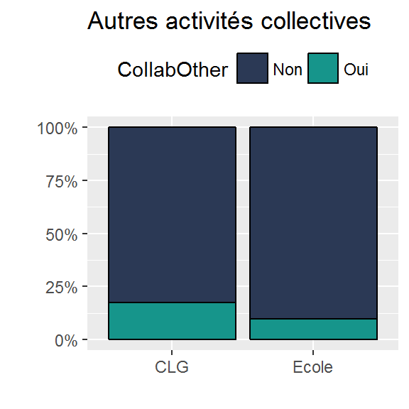

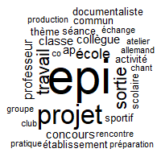

# 2)* Depuis septembre 2017, avec combien de collègues travaillez-vous directement?

Cette question mesure le nombre de collègues impliqués dans l’élaboration de deux types d’activités collectives. Elle considère d’une part des activités “x”, ordonnées de la préparation de cours aux projets académiques, d’autre part des activités “y”, ordonnées à l’inverse. La catégorie “autre” est proposée en l’absence de toute autre réponse.

## Activité collective x

`NbCProxE`

*j’ai élaboré des activités x avec environ n collègue(s)*

| Type d’activité | Effectif au collège | Effectif en élémentaire | % au collège | % en élémentaire | Nb de collègues CLG | Nb de collègues El |
| --- | --- | --- | --- | --- | --- | --- |
| cours ou séquences d’activités | 299 | 149 | 61.1 | 45.6 | 3.2 | 2.6 |
| travaux d’évaluations pour les élèves | 64 | 15 | 13.1 | 4.6 | 2.9 | 2.7 |
| projets d’interclasse | 61 | 82 | 12.5 | 25.1 | 3.7 | 2.9 |
| projets de cycle ou d’établissement | 34 | 57 | 7 | 17.4 | 3.7 | 3 |
| projets inter-établissements | 8 | 10 | 1.6 | 3.1 | 2 | 3.1 |
| projets académiques | 1 | 1 | 0.2 | 0.3 | 9 | 10 |
| autres types d’activités collectives | 0 | 0 | 0 | 0 | NaN | NaN |

## Activité collective y

`NbCProxI`

*codage à reprendre*

284 enseignants des collèges et 187 des écoles ont déclaré au moins deux activités.

| Type d’activité | Effectif au collège | Effectif en élémentaire | % au collège | % en élémentaire | Nb de collègues CLG | Nb de collègues El |
| --- | --- | --- | --- | --- | --- | --- |
| travaux d’évaluations pour les élèves | 66 | 17 | 23.2 | 9.1 | 2.8 | 2.1 |
| projets d’interclasse | 70 | 20 | 24.6 | 10.7 | 3 | 2.3 |
| projets de cycle ou d’établissement | 93 | 89 | 32.7 | 47.6 | 3.4 | 3.8 |
| projets inter-établissements | 32 | 54 | 11.3 | 28.9 | 3.1 | 4.1 |
| projets académiques | 9 | 5 | 3.2 | 2.7 | 2.9 | 3.4 |
| autres types d’activités collectives | 0 | 0 | 0 | 0 | NaN | NaN |

# 3)* A quelle fréquence travaillez-vous avec des collègues pour préparer des activités x?

Parmi les 816 enseignants qui ont déclaré avoir préparé une activité ou un projet avec leurs collègues depuis septembre, 183 (22.4%) ont déclaré préparer une ou plusieurs fois par semaine avec leurs collègues l’activité x (principalement la préparation de cours, mais il faudra détailler).

*une ou plusieurs fois par*

`CollabFreq` (p 7.4%)

|  | #Total | CLG | Ecole |
| --- | --- | --- | --- |
| dHC$CollabFreq |  |  |  |
| An | 10.7 | 12.9 | 7.3 |
| Trimestre | 24.9 | 24.5 | 25.4 |
| Mois | 39.7 | 37.6 | 42.8 |
| Hebdo | 22.4 | 23.1 | 21.4 |
| Jour | 2.3 | 1.8 | 3.1 |
| #Total cases | 816 | 489 | 327 |

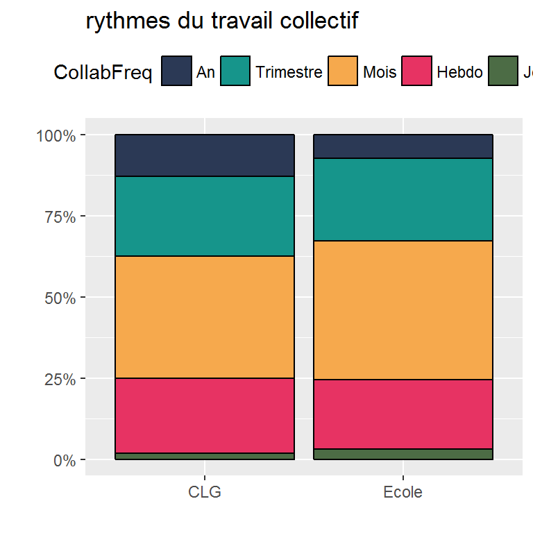

# 4)* Votre dernière préparation collective de x avec des collègues a duré:

Parmi les 816 enseignants qui ont déclaré avoir préparé une activité ou un projet avec leurs collègues depuis septembre, 364 (44.6%) estiment leur dernière préparation collective à 30 à 60 minutes .

*environ*

`CollabTps` (p 0%)

|  | #Total | CLG | Ecole |
| --- | --- | --- | --- |
| dHC$CollabTps |  |  |  |
| moins de 30 minutes | 22.1 | 26 | 16.2 |
| de 30 à 60 minutes | 44.6 | 42.7 | 47.4 |
| de 60 à 90 minutes | 19 | 15.1 | 24.8 |
| plus d’1h30 | 14.3 | 16.2 | 11.6 |
| #Total cases | 816 | 489 | 327 |

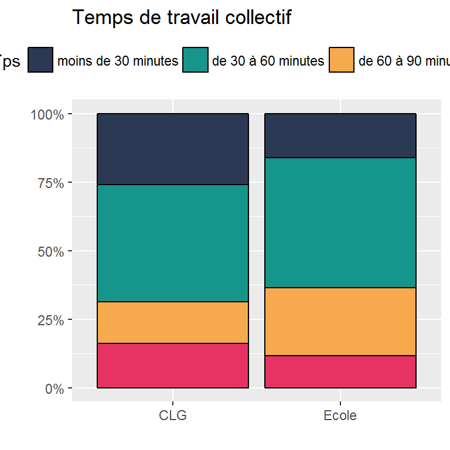

# B. Le contexte professionnel du travail entre enseignants

# 8)* Le collègue avec qui je travaille le plus souvent pour préparer des x, enseigne…

## Etablissement

Parmi les 816 enseignants ayant préparé des activités x avec leur collègue depuis septembre 2017, 740 (90.7%) ont le plus souvent travaillé avec un enseignant du même établissement.

`EtabCollegue` (p 0.7%)

|  | #Total | CLG | Ecole |
| --- | --- | --- | --- |
| dHC$EtabCollegue |  |  |  |
| dans mon école ou établissement | 90.7 | 93 | 87.2 |
| dans une autre école ou établissement | 9.3 | 7 | 12.8 |
| #Total cases | 816 | 489 | 327 |

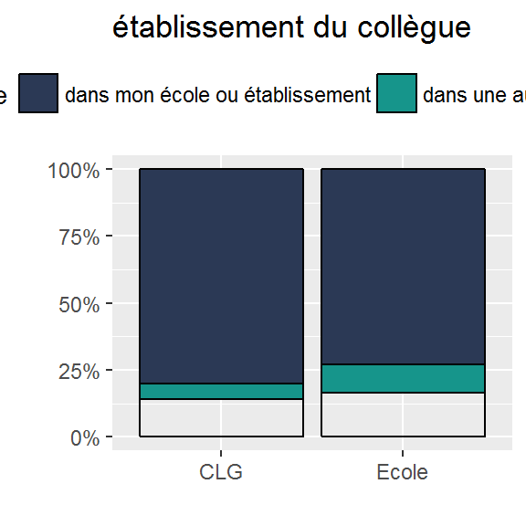

## Cycle

`CycleCollegue` (p 1.310^{-86}%)

|  | #Total | CLG | Ecole |
| --- | --- | --- | --- |
| dHC$CycleCollegue |  |  |  |
| Cycle2 | 12.9 | 1 | 30.6 |
| Cycle3 | 47.1 | 32.3 | 69.1 |
| Cycle4 | 40.1 | 66.7 | 0.3 |
| #Total cases | 816 | 489 | 327 |

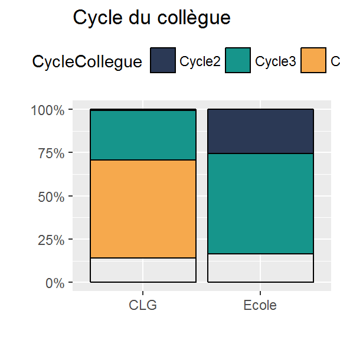

# C. L’usage du numérique par les enseignants

# 11)* “Pour travailler avec mes collègues”/“Pour mon travail pédagogique”, j’utilise les supports numériques suivants:

Cette question porte sur deux ensembles distincts d’enseignants ayant validé le questionnaire:  
- “Pour travailler avec mes collègues” concerne les 816 enseignants qui ont déclaré une activité collective avec leurs collègues.  
- “Pour mon travail pédagogique” concerne les 156 enseignants qui ont déclaré travailler seuls depuis septembre 2017.

## Usage collectif des supports

Parmi les 816 enseignants ayant préparé une activité avec leurs collègues, 532 (65.2%) ont utilisé un ordinateur de l’établissement pour travailler avec. 368 enseignants des collèges déclarent utiliser leur ordinateur personnel pour travailler avec leurs collègues.

*Pour travailler avec mes collègues, j’utilise les supports numériques suivants:*

| `SupportsNum_` | Effectif au collège | Effectif en élémentaire | % au collège | % en élémentaire | % Total |
| --- | --- | --- | --- | --- | --- |
| Ordinateur personnel `OrdiP` | 368 | 231 | 75.3 | 70.6 | 73.4 |
| Ordinateur de l’école `OrdiE` | 319 | 213 | 65.2 | 65.1 | 65.2 |
| Smartphone `Phone` | 183 | 95 | 37.4 | 29.1 | 34.1 |
| Tablette `Tab` | 59 | 9 | 12.1 | 2.8 | 8.3 |
| aucun support numérique `0` | 19 | 14 | 3.9 | 4.3 | 4 |
| TOTAL | 489 | 327 |  |  | 816 |

`OrdiE` (p 100%) `OrdiP` (p 16.7%) `Tab` (p 4.510^{-4}%) `Phone` (p 1.7%) `Non Usager` (p 92%)

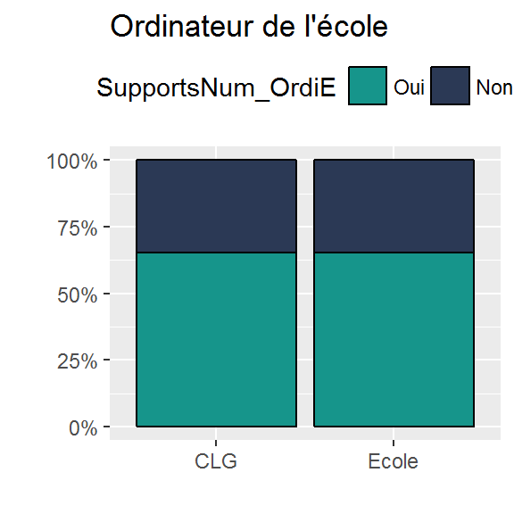

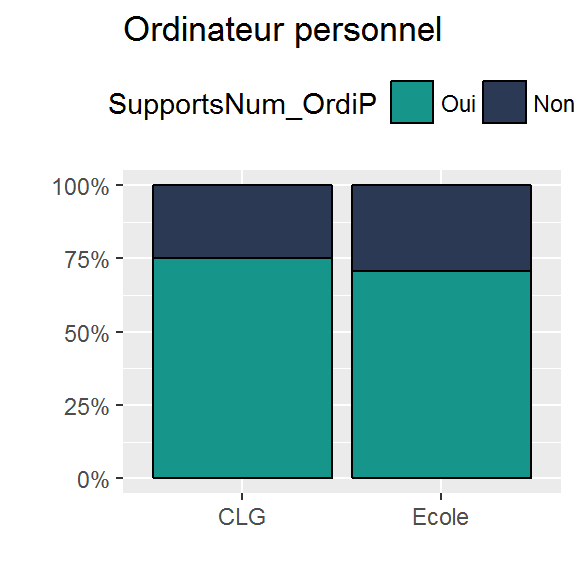

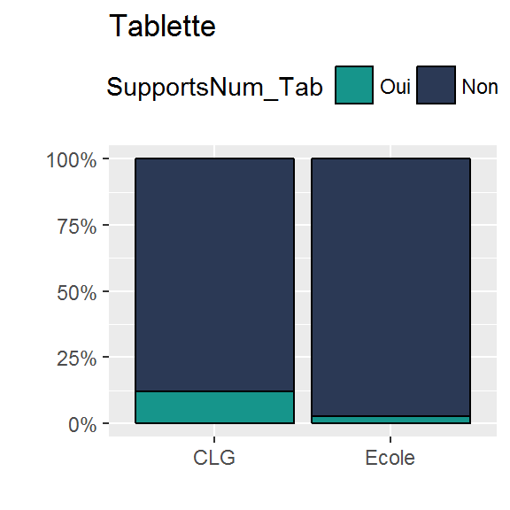

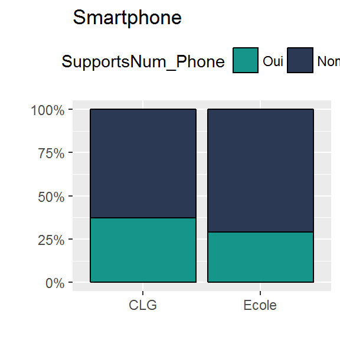

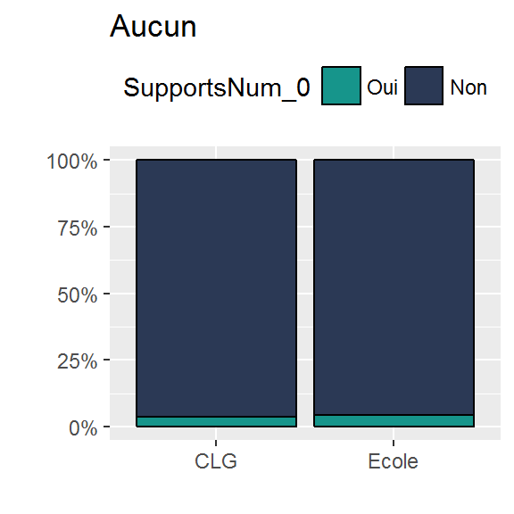

## Usage individuel des supports

Parmi les 156 enseignants ayant travaillé seuls depuis septembre 2017, 128 (82.1%) ont utilisé un ordinateur de l’établissement pour leur travail pédagogique. 72 enseignants des collèges déclarent utiliser leur ordinateur personnel pour leur travail pédagogique.

*Pour mon travail pédagogique, j’utilise les supports numériques suivants:*

| Support | Effectif au collège | Effectif en élémentaire | % au collège | % en élémentaire | % Total |
| --- | --- | --- | --- | --- | --- |
| Ordinateur personnel | 72 | 63 | 83.7 | 90 | 86.5 |
| Ordinateur de l’école | 79 | 49 | 91.9 | 70 | 82.1 |
| Smartphone | 25 | 13 | 29.1 | 18.6 | 24.4 |
| Tablette | 9 | 10 | 10.5 | 14.3 | 12.2 |
| aucun support numérique | 0 | 1 | 0 | 1.4 | 0.6 |
| TOTAL | 86 | 70 |  |  | 156 |

`OrdiE` (p 0.1%) `OrdiP` (p 36.4%) `Tab` (p 63.2%) `Phone` (p 18.3%) `0` (p 91.8%)

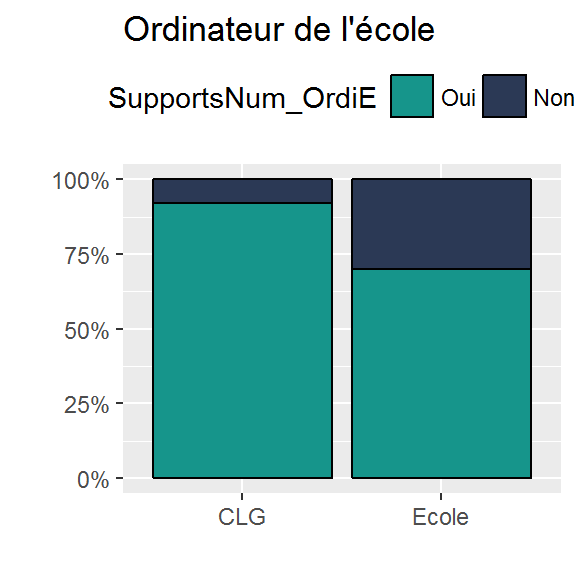

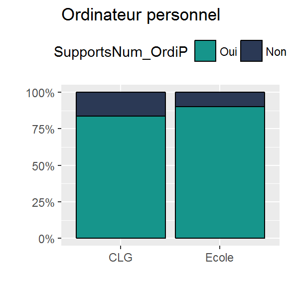

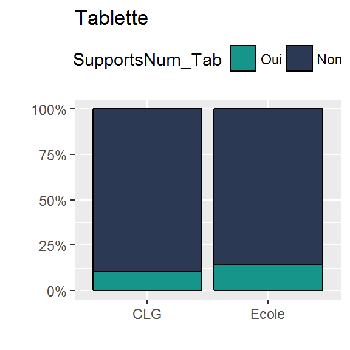

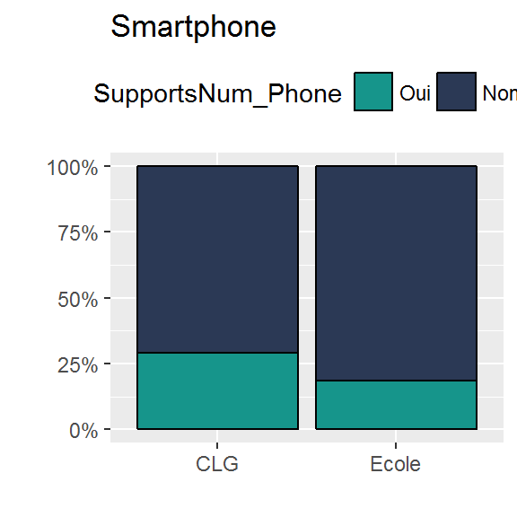

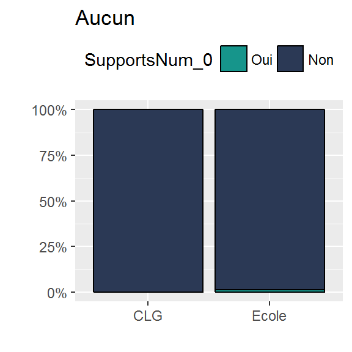

# 12)* “Pour travailler avec mes collègues”/“Pour mon travail pédagogique”, j’utilise les services numériques suivants:

Comme la précédente, cette question porte sur deux ensembles distincts d’enseignants ayant validé le questionnaire, moins ceux qui viennent de déclarer ne pas utiliser de supports numériques:  
- “Pour travailler avec mes collègues” concerne les 783 enseignants qui ont déclaré une activité collective avec leurs collègues.  
- “Pour mon travail pédagogique” concerne les 155 enseignants qui ont déclaré travailler seuls depuis septembre 2017.